# Labeled Property Graphs as a Methodological Framework

Supplementary Material

Juan C. Correa

August 2, 2026

This is the supplementary material for our work titled *“Labeled Property Graphs as a Methodological Framework”* published in Suma Psicologica. Our tutorial focuses on the phenomenon of sex differences in mate preferences (Eastwick & Finkel, 2008) and its Speed-Dating replication dataset (D. F. Selterman et al., 2015; D. F. Selterman et al., 2023).

# STEP 1: Original data source, preprocesing and loading

The original dataset is available in the following [OSF repository](https://osf.io/ng6cc/overview). In the Files Preview menu, the reader will find the speed.dating.syntax.2.zip file. This zip file contains several files, but the dataset is a .sav file called “speed.dating.3lev.small.july25.2014.sav”. We use RStudio to open this .sav file and export it as a standard coma separated values format (.csv) as the following syntax shows

```r
library(haven)
speed_dating <- read_sav("speed.dating.3lev.small.july25.2014.sav")
speed_dating <- as.data.frame(lapply(speed_dating, function(x) {
if (inherits(x, "haven_labelled")) {
as.numeric(x)
} else {
x
}}))
write.csv(speed_dating,"speed_dating.csv",row.names = FALSE, na = "")
```

Once exported this file, we use this “speed_dating.csv” as our input file in Neo4j and design our graph schema.

# STEP 1: Schema Design

The Speed-Dating dataset was represented using three node types and four relationship types.

Node types:

- Participant
- DateRating
- FollowUp

Relationship types:

- HAD_DATE
- WITH
- FOLLOWED_UP
- REPORTED_BY

DateRating nodes represent directed perceptual events from a rater toward a partner. FollowUp nodes represent week-level longitudinal assessments. Our suggested schema look like as the following figure:

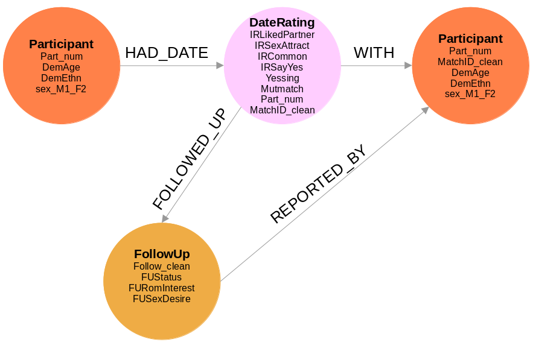

A labeled property graph of the speed-dating dataset by Selterman et al. (2023)

# STEP 2: Data Preparation in R

```r
library(haven)

speed_dating <- read_sav(
  "speed.dating.3lev.small.july25.2014.sav"
)

speed_dating <- as.data.frame(
  lapply(speed_dating, function(x) {
    if (inherits(x, "haven_labelled")) {
      as.numeric(x)
    } else {
      x
    }
  })
)

write.csv(
  speed_dating,
  "speed_dating.csv",
  row.names = FALSE,
  na = ""
)
```

# STEP 3: Import into Neo4j

## Constraints

```
CREATE CONSTRAINT participant_unique IF NOT EXISTS
FOR (p:Participant)
REQUIRE p.Part_num IS UNIQUE;

CREATE CONSTRAINT daterating_unique IF NOT EXISTS
FOR (d:DateRating)
REQUIRE d.date_rating_id IS UNIQUE;

CREATE INDEX followup_lookup IF NOT EXISTS
FOR (f:FollowUp)
ON (f.follow_id);
```

## Participant Nodes

Participants are instantiated from both `Part_num` and `MatchID_clean`.

```
LOAD CSV WITH HEADERS
FROM 'file:///speed_dating.csv' AS row

WITH row
WHERE trim(row.Part_num) <> ""

MERGE (p:Participant {
  Part_num: toInteger(row.Part_num)
});
```

```
LOAD CSV WITH HEADERS
FROM 'file:///speed_dating.csv' AS row

WITH row
WHERE trim(row.MatchID_clean) <> ""

MERGE (p:Participant {
  Part_num: toInteger(row.MatchID_clean)
});
```

## DateRating Nodes

```
LOAD CSV WITH HEADERS
FROM 'file:///speed_dating.csv' AS row

WITH row
WHERE toInteger(row.Follow_clean)=1

MERGE (d:DateRating {
  date_rating_id:
    row.Part_num + '_' +
    row.MatchID_clean
})

SET
d.Part_num = toInteger(row.Part_num),
d.MatchID_clean = toInteger(row.MatchID_clean),
d.IRLikedPartner =
  toFloat(row.IRLikedPartner),
d.IRSexAttract =
  toFloat(row.IRSexAttract),
d.IRCommon =
  toFloat(row.IRCommon),
d.IRSayYes =
  toFloat(row.IRSayYes),
d.Yessing =
  toInteger(row.yessing),
d.Mutmatch =
  toInteger(row.mutmatch);
```

## FollowUp Nodes

```
LOAD CSV WITH HEADERS
FROM 'file:///speed_dating.csv' AS row

WITH row

WHERE
trim(row.FURomInterest) <> ''
OR trim(row.FUSexDesire) <> ''
OR trim(row.FUCommitted) <> ''
OR trim(row.FUStatus) <> ''

MERGE (f:FollowUp {

follow_id:
row.Part_num + '_'
+ row.MatchID_clean + '_'
+ row.Follow_clean

});
```

## Relationships

[output not shown]

# STEP 4: Verification and Analytical Queries

## Verification Query 1

DateRating node count

```
MATCH (d:DateRating)
RETURN count(d) AS date_ratings;
```

Expected result:

```
2816
```

## Verification Query 2

FollowUp node count

```
MATCH (f:FollowUp)
RETURN count(f) AS followups;
```

Expected result:

```
1152
```

## Query A:

Perceptual Asymmetry in Mutual-Match Dyads

```
// Query A: Perceptual asymmetry in mutual-match dyads
MATCH (a:Participant)-[:HAD_DATE]->(d1:DateRating {Mutmatch: 1})
      -[:WITH]->(b:Participant),
      (b)-[:HAD_DATE]->(d2:DateRating {Mutmatch: 1})-[:WITH]->(a)
WHERE a.Part_num < b.Part_num
  AND d1.IRLikedPartner IS NOT NULL
  AND d2.IRLikedPartner IS NOT NULL
RETURN a.Part_num                                      AS rater_a,
       b.Part_num                                      AS rater_b,
       d1.IRLikedPartner                               AS a_liked_b,
       d2.IRLikedPartner                               AS b_liked_a,
       abs(d1.IRLikedPartner - d2.IRLikedPartner)      AS asymmetry
ORDER BY asymmetry DESC;
```

Expected results reported in manuscript:

```
83 mutual-match dyads
71.1% non-zero asymmetry
Mean = 1.19
SD = 1.29
27.7% ≥ 2 points
```

## Query B:

DateRating Nodes

```
// Query B: DateRating Nodes
MATCH (d:DateRating)
RETURN count(d) AS date_ratings;
```

Expected:

```
2816
```

## Query C:

FollowUp Nodes

```
// Query C: FollowUp Node Count
MATCH (f:FollowUp)
RETURN count(f) AS followups;
```

Expected:

```
1152
```

## Query D:

Structural Absence Rate

```
// Query D: Structural Absence Rate
MATCH (d:DateRating)
WITH count(d) AS n_dates

MATCH (f:FollowUp)
RETURN n_dates,
       n_dates * 10 AS potential_combinations,
       count(f) AS realized_followups,
       round(
         1000.0 * ((n_dates * 10) - count(f))
         / (n_dates * 10)
       ) / 10 AS absence_rate;
```

Expected output:

```
28160 potential combinations
1152 realized FollowUp nodes
95.9% structural absence
```

## Query E:

Partner Exposure

```
// Query E: Partner in-degree and mean received rating
MATCH (d:DateRating)-[:WITH]->(partner:Participant)
WITH  partner,
      count(d)              AS n_raters,
      avg(d.IRLikedPartner) AS mean_received_rating,
      stdev(d.IRLikedPartner) AS sd_received_rating
RETURN partner.Part_num    AS partner_id,
       n_raters,
       round(mean_received_rating, 2) AS mean_received_rating,
       round(sd_received_rating,  2)  AS sd_received_rating
ORDER BY mean_received_rating DESC;
```

Expected descriptive results:

```
1 to 20 raters
Mean = 7.45
SD = 3.35
```

# STEP 5: Export and Statistical Evaluation

## Query F

```
// Query F: Export data for multilevel model
MATCH (p:Participant)-[:HAD_DATE]->(d:DateRating)-[:FOLLOWED_UP]->(f:FollowUp)
WHERE d.IRLikedPartner IS NOT NULL
  AND f.FURomInterest  IS NOT NULL
RETURN p.Part_num        AS participant,
       d.MatchID_clean   AS partner,
       p.sex_M1_F2       AS sex,
       d.IRLikedPartner  AS initial_attraction,
       d.Mutmatch        AS mutual_match,
       f.Follow_clean    AS week,
       f.FURomInterest   AS romantic_interest
ORDER BY participant, partner, week;
```

Export as:

```
query_export.csv
```

# Crossed Random-Effects Model

```r
library(lme4)
library(lmerTest)

dating_graph <- read.csv(
  "query_export.csv"
)

dating_graph$participant <-
  factor(
    dating_graph$participant
  )

dating_graph$partner <-
  factor(
    dating_graph$partner
  )

dating_graph$initial_attraction_c <-
  scale(
    dating_graph$initial_attraction,
    center = TRUE,
    scale = FALSE
  )

dating_graph$week_c <-
  dating_graph$week - 1

model_crossed <- lmer(

romantic_interest ~

initial_attraction_c +
week_c +
sex +

initial_attraction_c:
week_c +

(1 | participant) +
(1 | partner),

data = dating_graph,

REML = TRUE,

control =
  lmerControl(
    optimizer = "bobyqa"
  )
)

summary(model_crossed)
```

# Reproducing Table 3

```r
coef(
  summary(model_crossed)
)
```

```r
VarCorr(model_crossed)
```

```r
nobs(model_crossed)
```

```r
length(
  unique(
    dating_graph$participant
  )
)
```

```r
length(
  unique(
    dating_graph$partner
  )
)
```

```r
length(
  unique(
    paste(
      dating_graph$participant,
      dating_graph$partner
    )
  )
)
```

```r
isSingular(
  model_crossed
)
```

Expected outputs:

[output not shown]

Now, we can show other statistics

```r
fixed_effects <- data.frame(
 coef(summary(model_crossed))
)

fixed_effects

variance_components <- as.data.frame(
 VarCorr(model_crossed)
)

variance_components

# Number of observations
nobs(model_crossed)

# Participants
length(unique(dating_graph$participant))

# Partners
length(unique(dating_graph$partner))

# Unique rater-partner pairs
length(unique(
 paste(
  dating_graph$participant,
  dating_graph$partner
 )
))
```

# References

Eastwick, P. W., & Finkel, E. J. (2008). Sex differences in mate preferences revisited: Do people know what they initially desire in a romantic partner? *Journal of Personality and Social Psychology*, *94*(2), 245. https://doi.org/10.1037/0022-3514.94.2.245

Selterman, D. F., Chagnon, E., & Mackinnon, S. P. (2015). Do Men and Women Exhibit Different Preferences for Mates? A Replication of Eastwick and Finkel (2008). *SAGE Open*, *5*(3), 1–14. https://doi.org/10.1177/2158244015605160

Selterman, D. F., Chagnon, E., & Mackinnon, S. P. (2023). *Replication of Eastwick and Finkel (2008, JPSP)*. Open Science Framework. https://osf.io/ng6cc/overview